# Assignment4

2023-11-09

# Problem 1

```r
churn_data <- read.csv("churn_train.csv", header = TRUE, sep = ",")
head(churn_data)
```

```
##   GENDER EDUCATION LAST_PRICE_PLAN_CHNG_DAY_CNT TOT_ACTV_SRV_CNT AGE
## 1      M         2                            0                1  36
## 2      M         .                            0                4  33
## 3      F         1                            0                1  37
## 4      M         1                            0                3  58
## 5      F         1                            0                3  38
## 6      M         2                            0                3  42
##   PCT_CHNG_IB_SMS_CNT PCT_CHNG_BILL_AMT CHURN COMPLAINT
## 1           0.8421053         0.5709716     0         0
## 2           1.3969849         1.1955521     0         1
## 3           0.6440678         0.9074558     0         1
## 4           1.8245614         1.1771058     0         1
## 5           0.4507042         1.0892169     0         1
## 6           1.0860215         0.7079038     0         1
```

```r
yvar=churn_data[,8]
```

```r
summary(churn_data)
```

```
##     GENDER           EDUCATION         LAST_PRICE_PLAN_CHNG_DAY_CNT
##  Length:983         Length:983         Min.   :0.00000
##  Class :character   Class :character   1st Qu.:0.00000
##  Mode  :character   Mode  :character   Median :0.00000
##                                        Mean   :0.02543
##                                        3rd Qu.:0.00000
##                                        Max.   :1.00000
##  TOT_ACTV_SRV_CNT      AGE        PCT_CHNG_IB_SMS_CNT PCT_CHNG_BILL_AMT
##  Min.   :0.000    Min.   :20.00   Min.   :0.04878     Min.   :0.3169
##  1st Qu.:0.000    1st Qu.:24.00   1st Qu.:0.79057     1st Qu.:0.7850
##  Median :2.000    Median :28.00   Median :1.08602     Median :1.0342
##  Mean   :1.959    Mean   :34.07   Mean   :1.19733     Mean   :1.0996
##  3rd Qu.:3.000    3rd Qu.:44.00   3rd Qu.:1.50965     3rd Qu.:1.3417
##  Max.   :7.000    Max.   :62.00   Max.   :6.16667     Max.   :3.1850
##      CHURN          COMPLAINT
##  Min.   :0.0000   Min.   :0.000
##  1st Qu.:0.0000   1st Qu.:1.000
##  Median :0.0000   Median :1.000
##  Mean   :0.4761   Mean   :0.763
##  3rd Qu.:1.0000   3rd Qu.:1.000
##  Max.   :1.0000   Max.   :1.000
```

```r
#Converting Target variable to factor
churn_data$CHURN <- factor(churn_data$CHURN, levels = c(0, 1), labels = c("No", "Yes"))
str(churn_data)
```

```
## 'data.frame':    983 obs. of  9 variables:
##  $ GENDER                      : chr  "M" "M" "F" "M" ...
##  $ EDUCATION                   : chr  "2" "." "1" "1" ...
##  $ LAST_PRICE_PLAN_CHNG_DAY_CNT: int  0 0 0 0 0 0 0 0 0 0 ...
##  $ TOT_ACTV_SRV_CNT            : int  1 4 1 3 3 3 2 3 4 1 ...
##  $ AGE                         : int  36 33 37 58 38 42 42 57 30 55 ...
##  $ PCT_CHNG_IB_SMS_CNT         : num  0.842 1.397 0.644 1.825 0.451 ...
##  $ PCT_CHNG_BILL_AMT           : num  0.571 1.196 0.907 1.177 1.089 ...
##  $ CHURN                       : Factor w/ 2 levels "No","Yes": 1 1 1 1 1 1 1 1 1 1 ...
##  $ COMPLAINT                   : int  0 1 1 1 1 1 0 0 1 0 ...
```

1. Create two boxplots to analyze the observed values of age and PCT_CHNG_BILL_AMT by churn value. Analyze the boxplots and discuss how customer age and changes in bill amount affect churn probabilities. [1 pt for R code for boxplots, 1 pt for analysis = 2 pts]

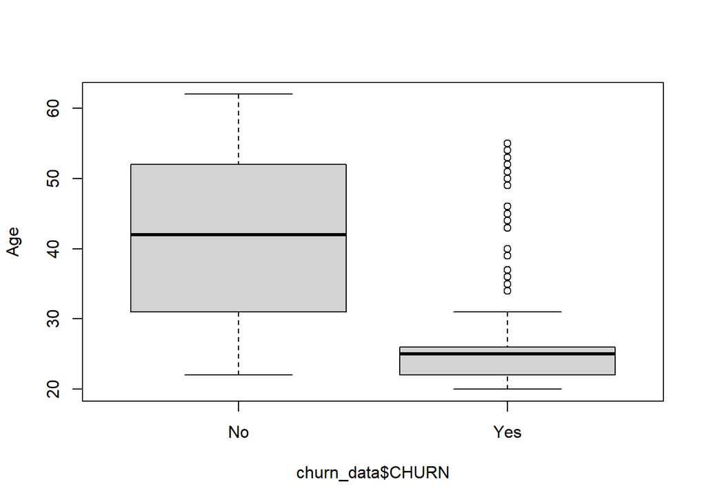

```r
boxplot(churn_data$AGE~churn_data$CHURN,ylab = "Age")
```

The “No” data is distributed with a median age around 40, indicated by the line inside the box.The box, representing the interquartile range (IQR), shows that the middle 50% of the data falls roughly between the early 30s and the slightly over 50s.There do not appear to be any outliers beyond the whiskers, suggesting that most individuals’ ages fall within a relatively expected range.The median age of “Yes” data is lower, closer to the 20s.The IQR is narrower, indicating that the middle 50% of ages in this group is more concentrated around the median.

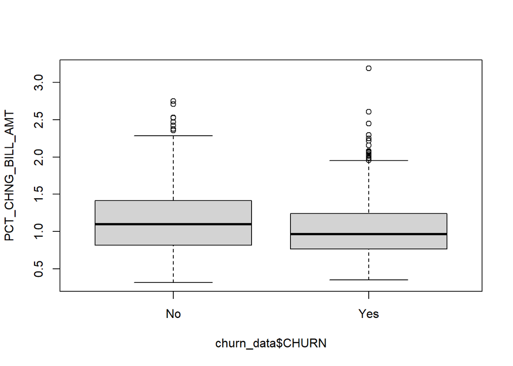

```r
boxplot(churn_data$PCT_CHNG_BILL_AMT~churn_data$CHURN,ylab = "PCT_CHNG_BILL_AMT")
```

2. Fit a logistic regression model to predict the churn probability using the data in the dataset (Churn is the response variable and the remaining variables are the independent x-variables). Remove x-variables that are not significant using alpha=0.05. Write down the expression of the fitted model. (HINT: probability of interest is p = pr(churn = 1)

```r
library(car)
model_1 <- glm(CHURN ~ ., family = binomial(link = "logit"), data = churn_data)
summary(model_1)
```

```
##
## Call:
## glm(formula = CHURN ~ ., family = binomial(link = "logit"), data = churn_data)
##
## Coefficients:
##                               Estimate Std. Error z value Pr(>|z|)
## (Intercept)                    6.43494    1.97935   3.251  0.00115 **
## GENDERF                        0.37170    1.90624   0.195  0.84540
## GENDERM                        0.28369    1.90439   0.149  0.88158
## EDUCATION1                     0.47772    0.25127   1.901  0.05728 .
## EDUCATION2                     0.36377    0.25260   1.440  0.14983
## EDUCATION3                     0.80136    0.62368   1.285  0.19883
## EDUCATION4                     1.16679    0.99002   1.179  0.23858
## EDUCATION5                    12.87920  623.78082   0.021  0.98353
## EDUCATION6                     1.09081    1.75631   0.621  0.53455
## LAST_PRICE_PLAN_CHNG_DAY_CNT   0.21474    0.56433   0.381  0.70356
## TOT_ACTV_SRV_CNT              -0.55387    0.06368  -8.698  < 2e-16 ***
## AGE                           -0.17767    0.01272 -13.970  < 2e-16 ***
## PCT_CHNG_IB_SMS_CNT           -0.39073    0.14425  -2.709  0.00676 **
## PCT_CHNG_BILL_AMT             -0.41377    0.22336  -1.852  0.06396 .
## COMPLAINT                      0.52141    0.22683   2.299  0.02152 *
## ---
## Signif. codes:  0 '***' 0.001 '**' 0.01 '*' 0.05 '.' 0.1 ' ' 1
##
## (Dispersion parameter for binomial family taken to be 1)
##
##     Null deviance: 1360.48  on 982  degrees of freedom
## Residual deviance:  714.66  on 968  degrees of freedom
## AIC: 744.66
##
## Number of Fisher Scoring iterations: 13
```

Removing non significant variables.

```r
significant_model<-step(model_1,direction="backward")
```

```
## Start:  AIC=744.66
## CHURN ~ GENDER + EDUCATION + LAST_PRICE_PLAN_CHNG_DAY_CNT + TOT_ACTV_SRV_CNT +
##     AGE + PCT_CHNG_IB_SMS_CNT + PCT_CHNG_BILL_AMT + COMPLAINT
##
##                                Df Deviance     AIC
## - EDUCATION                     6   720.58  738.58
## - GENDER                        2   714.87  740.87
## - LAST_PRICE_PLAN_CHNG_DAY_CNT  1   714.80  742.80
## <none>                              714.66  744.66
## - PCT_CHNG_BILL_AMT             1   718.12  746.12
## - COMPLAINT                     1   719.94  747.94
## - PCT_CHNG_IB_SMS_CNT           1   721.96  749.96
## - TOT_ACTV_SRV_CNT              1   802.80  830.80
## - AGE                           1  1125.96 1153.96
##
## Step:  AIC=738.58
## CHURN ~ GENDER + LAST_PRICE_PLAN_CHNG_DAY_CNT + TOT_ACTV_SRV_CNT +
##     AGE + PCT_CHNG_IB_SMS_CNT + PCT_CHNG_BILL_AMT + COMPLAINT
##
##                                Df Deviance     AIC
## - GENDER                        2   720.78  734.78
## - LAST_PRICE_PLAN_CHNG_DAY_CNT  1   720.68  736.68
## <none>                              720.58  738.58
## - PCT_CHNG_BILL_AMT             1   723.91  739.91
## - COMPLAINT                     1   725.81  741.81
## - PCT_CHNG_IB_SMS_CNT           1   728.72  744.72
## - TOT_ACTV_SRV_CNT              1   809.10  825.10
## - AGE                           1  1134.17 1150.17
##
## Step:  AIC=734.78
## CHURN ~ LAST_PRICE_PLAN_CHNG_DAY_CNT + TOT_ACTV_SRV_CNT + AGE +
##     PCT_CHNG_IB_SMS_CNT + PCT_CHNG_BILL_AMT + COMPLAINT
##
##                                Df Deviance     AIC
## - LAST_PRICE_PLAN_CHNG_DAY_CNT  1   720.87  732.87
## <none>                              720.78  734.78
## - PCT_CHNG_BILL_AMT             1   724.14  736.14
## - COMPLAINT                     1   725.96  737.96
## - PCT_CHNG_IB_SMS_CNT           1   728.96  740.96
## - TOT_ACTV_SRV_CNT              1   809.15  821.15
## - AGE                           1  1134.52 1146.52
##
## Step:  AIC=732.87
## CHURN ~ TOT_ACTV_SRV_CNT + AGE + PCT_CHNG_IB_SMS_CNT + PCT_CHNG_BILL_AMT +
##     COMPLAINT
##
##                       Df Deviance     AIC
## <none>                     720.87  732.87
## - PCT_CHNG_BILL_AMT    1   724.17  734.17
## - COMPLAINT            1   725.99  735.99
## - PCT_CHNG_IB_SMS_CNT  1   729.03  739.03
## - TOT_ACTV_SRV_CNT     1   809.68  819.68
## - AGE                  1  1134.53 1144.53
```

Here we applied step function inorder to find best model. we got CHURN ~ TOT_ACTV_SRV_CNT + AGE + PCT_CHNG_IB_SMS_CNT + PCT_CHNG_BILL_AMT + COMPLAINT this model as best AIC value of 732.87 which is lowest of all. It still has one non-significant variable, i tried removing it but does make much difference and it also increases the AIC value so i moved with the model with AIC 732.87.

```r
summary(significant_model)
```

```
##
## Call:
## glm(formula = CHURN ~ TOT_ACTV_SRV_CNT + AGE + PCT_CHNG_IB_SMS_CNT +
##     PCT_CHNG_BILL_AMT + COMPLAINT, family = binomial(link = "logit"),
##     data = churn_data)
##
## Coefficients:
##                     Estimate Std. Error z value Pr(>|z|)
## (Intercept)          7.11401    0.53506  13.296   <2e-16 ***
## TOT_ACTV_SRV_CNT    -0.54892    0.06282  -8.738   <2e-16 ***
## AGE                 -0.17781    0.01270 -14.002   <2e-16 ***
## PCT_CHNG_IB_SMS_CNT -0.41230    0.14403  -2.863   0.0042 **
## PCT_CHNG_BILL_AMT   -0.39914    0.22057  -1.810   0.0704 .
## COMPLAINT            0.50489    0.22283   2.266   0.0235 *
## ---
## Signif. codes:  0 '***' 0.001 '**' 0.01 '*' 0.05 '.' 0.1 ' ' 1
##
## (Dispersion parameter for binomial family taken to be 1)
##
##     Null deviance: 1360.48  on 982  degrees of freedom
## Residual deviance:  720.87  on 977  degrees of freedom
## AIC: 732.87
##
## Number of Fisher Scoring iterations: 6
```

The expression for regression model is CHURN ~ β0+β1×TOT_ACTV_SRV_CNT +β2× AGE +β3× PCT_CHNG_IB_SMS_CNT + β4×PCT_CHNG_BILL_AMT + β5×COMPLAINT+ϵ CHURN = 7.11401 -0.54892TOT_ACTV_SRV_CNT -0.17781AGE -0.41230PCT_CHNG_IB_SMS_CNT -0.39914PCT_CHNG_BILL_AMT + 0.50489*COMPLAINT Non significant x-variables are:GENDER,EDUCATION , LAST_PRICE_PLAN_CHNG_DAY_CNT , PCT_CHNG_BILL_AMT

3. Analyze the final logistic regression model and discuss the effect of each variable on the churn probability. Discuss results in terms of odds ratios.

```r
model_2 <- glm(CHURN ~ TOT_ACTV_SRV_CNT + AGE + PCT_CHNG_IB_SMS_CNT + PCT_CHNG_BILL_AMT +
    COMPLAINT, family = binomial(link = "logit"), data = churn_data)
summary(model_2)
```

```
##
## Call:
## glm(formula = CHURN ~ TOT_ACTV_SRV_CNT + AGE + PCT_CHNG_IB_SMS_CNT +
##     PCT_CHNG_BILL_AMT + COMPLAINT, family = binomial(link = "logit"),
##     data = churn_data)
##
## Coefficients:
##                     Estimate Std. Error z value Pr(>|z|)
## (Intercept)          7.11401    0.53506  13.296   <2e-16 ***
## TOT_ACTV_SRV_CNT    -0.54892    0.06282  -8.738   <2e-16 ***
## AGE                 -0.17781    0.01270 -14.002   <2e-16 ***
## PCT_CHNG_IB_SMS_CNT -0.41230    0.14403  -2.863   0.0042 **
## PCT_CHNG_BILL_AMT   -0.39914    0.22057  -1.810   0.0704 .
## COMPLAINT            0.50489    0.22283   2.266   0.0235 *
## ---
## Signif. codes:  0 '***' 0.001 '**' 0.01 '*' 0.05 '.' 0.1 ' ' 1
##
## (Dispersion parameter for binomial family taken to be 1)
##
##     Null deviance: 1360.48  on 982  degrees of freedom
## Residual deviance:  720.87  on 977  degrees of freedom
## AIC: 732.87
##
## Number of Fisher Scoring iterations: 6
```

Expression: CHURN = 7.11401 + -0.54892TOT_ACTV_SRV_CNT + -0.17781AGE + -0.41230PCT_CHNG_IB_SMS_CNT + -0.39914PCT_CHNG_BILL_AMT + 0.50489*COMPLAINT

```r
library(car)
library(carData)
library(lmtest)
lrtest(model_2)
```

```
## Likelihood ratio test
##
## Model 1: CHURN ~ TOT_ACTV_SRV_CNT + AGE + PCT_CHNG_IB_SMS_CNT + PCT_CHNG_BILL_AMT +
##     COMPLAINT
## Model 2: CHURN ~ 1
##   #Df  LogLik Df  Chisq Pr(>Chisq)
## 1   6 -360.43
## 2   1 -680.24 -5 639.61  < 2.2e-16 ***
## ---
## Signif. codes:  0 '***' 0.001 '**' 0.01 '*' 0.05 '.' 0.1 ' ' 1
```

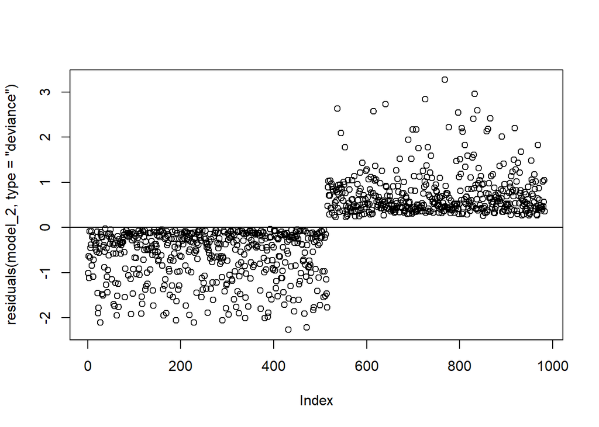

```r
#plot of residuals vs churn number
plot(residuals(model_2, type="deviance"))
abline(a=0, b=0)
```

```r
#coefficients
print(coef(model_2))
```

```
##         (Intercept)    TOT_ACTV_SRV_CNT                 AGE PCT_CHNG_IB_SMS_CNT
##           7.1140137          -0.5489231          -0.1778119          -0.4123012
##   PCT_CHNG_BILL_AMT           COMPLAINT
##          -0.3991370           0.5048868
```

```r
#odds ratio
odds_ratios <- exp(coef(model_2))
print(odds_ratios)
```

```
##         (Intercept)    TOT_ACTV_SRV_CNT                 AGE PCT_CHNG_IB_SMS_CNT
##        1229.0707704           0.5775714           0.8370999           0.6621248
##   PCT_CHNG_BILL_AMT           COMPLAINT
##           0.6708988           1.6567979
```

```r
#Confidence interval
confint_final_model <- exp(confint(model_2))
print(confint_final_model)
```

```
##                           2.5 %       97.5 %
## (Intercept)         445.7102966 3640.1413351
## TOT_ACTV_SRV_CNT      0.5092027    0.6515916
## AGE                   0.8155381    0.8572346
## PCT_CHNG_IB_SMS_CNT   0.4976629    0.8777333
## PCT_CHNG_BILL_AMT     0.4340643    1.0317529
## COMPLAINT             1.0703186    2.5668809
```

4. Compute the predicted churn probability and the prediction interval for a male customer who is 43 years old, and has the following information LAST_PRICE_PLAN_CHNG_DAY_CNT=0, TOT_ACTV_SRV_CN=4, PCT_CHNG_IB_SMS_CNT= 1.04, PCT_CHNG_BILL_AMT= 1.19, and COMPLAINT =1.

```r
new_data <- data.frame( TOT_ACTV_SRV_CNT = 4,AGE = 43, PCT_CHNG_IB_SMS_CNT = 1.04,PCT_CHNG_BILL_AMT = 1.19,COMPLAINT = 1)

# Calculate the predicted probability
predicted_prob <- predict(model_2, newdata = new_data, type = "response", se.fit=T)
print(predicted_prob)
```

```
## $fit
##          1
## 0.04202857
##
## $se.fit
##          1
## 0.01015331
##
## $residual.scale
## [1] 1
```

The predicted probability is 0.04202857.

```r
predicted_log_odds <- predict(model_2, newdata = new_data, type = "link", se = TRUE)

# Calculate confidence intervals on the log-odds scale
ci_log_odds <- with(predicted_log_odds,
                    fit + c(-1, 1) * qnorm(0.975) * se.fit)

# Transform the log-odds confidence intervals to probabilities
ci_prob <- plogis(ci_log_odds)

# Create a named vector for the confidence interval
ci_prob_named <- setNames(ci_prob, c("lower", "upper"))

# Print the confidence intervals for the predicted probabilities
print(ci_prob_named)
```

```
##      lower      upper
## 0.02606549 0.06709433
```

The confidence interval is for lower is 0.02606549 and 0.06709433 is for upper boundary.

5. The dataset churn_test.csv contains a new set of customers, and can be used to test the validity of the churn predictive model. Apply the methods discussed in week 8 lecture to identify a threshold T for the predicted churn probability in order to define a classification rule for customers, so that
- predicted probability p(churn) > = T, then customer is a “likely churn”, and
- predicted probability p(churn) < T, then customer is a “unlikely churn”. Compute the optimal T value, and create the classification matrix summarizing classification results. Hint: You can use the Classify_functions.R in your solution. [1 pt for R code for getting range of thresholds to choose optimal T, 1 pt for computing predicted churn outcomes corresponding to predicted probabilities, 1 pt for computing confusion matrix and metrics, 1 pt for selecting the P* that optimizes a certain metric, 1 pt for computing predicted churn outcomes for a separate testing set (churn_test.csv), 1 pt for computing the confusion matrix that summarizes classification results and metrics = 6 pts]

```r
churn_test <- read.csv("churn_test.csv", header = TRUE, sep = ",")
head(churn_test)
```

```
##   GENDER EDUCATION LAST_PRICE_PLAN_CHNG_DAY_CNT TOT_ACTV_SRV_CNT AGE
## 1      M         .                            0                4  33
## 2      M         .                            0                3  57
## 3      M         2                            0                2  24
## 4      M         1                            0                3  50
## 5      M         2                            0                3  26
## 6      M         2                            1                2  35
##   PCT_CHNG_IB_SMS_CNT PCT_CHNG_BILL_AMT CHURN COMPLAINT
## 1            1.396985         1.1955521     0         1
## 2            1.189189         1.1436224     0         0
## 3            1.563025         0.6654836     0         1
## 4            1.062500         1.3382473     0         1
## 5            1.012766         0.6653504     0         1
## 6            1.093458         1.4547685     0         1
```

```r
churn_test$CHURN = as.factor(churn_test$CHURN)
str(churn_test)
```

```
## 'data.frame':    98 obs. of  9 variables:
##  $ GENDER                      : chr  "M" "M" "M" "M" ...
##  $ EDUCATION                   : chr  "." "." "2" "1" ...
##  $ LAST_PRICE_PLAN_CHNG_DAY_CNT: int  0 0 0 0 0 1 0 0 0 0 ...
##  $ TOT_ACTV_SRV_CNT            : int  4 3 2 3 3 2 4 4 2 2 ...
##  $ AGE                         : int  33 57 24 50 26 35 29 45 54 43 ...
##  $ PCT_CHNG_IB_SMS_CNT         : num  1.4 1.19 1.56 1.06 1.01 ...
##  $ PCT_CHNG_BILL_AMT           : num  1.196 1.144 0.665 1.338 0.665 ...
##  $ CHURN                       : Factor w/ 2 levels "0","1": 1 1 1 1 1 1 1 1 1 1 ...
##  $ COMPLAINT                   : int  1 0 1 1 1 1 1 1 1 1 ...
```

```r
summary(churn_test)
```

```
##     GENDER           EDUCATION         LAST_PRICE_PLAN_CHNG_DAY_CNT
##  Length:98          Length:98          Min.   :0.00000
##  Class :character   Class :character   1st Qu.:0.00000
##  Mode  :character   Mode  :character   Median :0.00000
##                                        Mean   :0.02041
##                                        3rd Qu.:0.00000
##                                        Max.   :1.00000
##  TOT_ACTV_SRV_CNT      AGE        PCT_CHNG_IB_SMS_CNT PCT_CHNG_BILL_AMT CHURN
##  Min.   :0.000    Min.   :20.00   Min.   :0.1493      Min.   :0.3612    0:59
##  1st Qu.:1.000    1st Qu.:24.00   1st Qu.:0.8146      1st Qu.:0.7317    1:39
##  Median :2.000    Median :30.50   Median :1.0787      Median :0.9640
##  Mean   :2.061    Mean   :34.58   Mean   :1.1363      Mean   :1.0547
##  3rd Qu.:3.000    3rd Qu.:44.75   3rd Qu.:1.3793      3rd Qu.:1.3602
##  Max.   :6.000    Max.   :59.00   Max.   :3.2456      Max.   :2.3565
##    COMPLAINT
##  Min.   :0.0000
##  1st Qu.:1.0000
##  Median :1.0000
##  Mean   :0.7959
##  3rd Qu.:1.0000
##  Max.   :1.0000
```

```r
library(pROC)
```

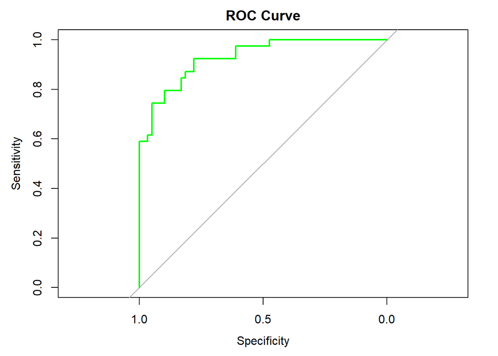

```r
test_predicted_prob <- predict(model_2, newdata = churn_test, type = "response")
roc_curve <- roc(churn_test$CHURN, test_predicted_prob)
plot(roc_curve, main = "ROC Curve", col = "green")
```

```r
optimal_threshold <- coords(roc_curve, "best", ret = "threshold")$threshold
optimal_threshold
```

```
## [1] 0.4838613
```

This is the threshold we got after analyzing the ROC curve.

```r
predict_classes <- ifelse(test_predicted_prob >= optimal_threshold, "likely churn", "unlikely churn")
```

```r
conf_matrix <- table(churn_test$CHURN, predict_classes)
conf_matrix
```

```
##    predict_classes
##     likely churn unlikely churn
##   0           13             46
##   1           36              3
```

```r
# Used the Classify_functions.R from Week 8
source("Classify_functions.R")
```

```r
sensitivity(conf_matrix)
```

```
## [1] 0.2653061
```

```r
specificity(conf_matrix)
```

```
## [1] 0.06122449
```

```r
accuracy(conf_matrix)
```

```
## [1] 0.1632653
```

```r
precision(conf_matrix)
```

```
## [1] 0.220339
```

```r
recall(conf_matrix)
```

```
## [1] 0.2653061
```

# Problem 2

1. Create a scatterplot of ENERGY (y) versus TEMPD (x) to visualize the association between the two variables. Analyze the association displayed by the scatterplot.

```r
energydata=read.table("energytemp.txt", header=T, sep="\t")
names(energydata)
```

```
## [1] "energy..temp"
```

```r
str(energydata)
```

```
## 'data.frame':    24 obs. of  1 variable:
##  $ energy..temp: chr  "16  1" "12  1" "7  1" "40  3" ...
```

```r
#Splitting the coloumns
library(tidyr)
energydata <- tidyr::separate(energydata, col = energy..temp, into = c("energy", "temp"), sep = "  ")

# Convert the new columns to integers
energydata$energy <- as.integer(energydata$energy)
energydata$temp <- as.integer(energydata$temp)

# Check the structure of the modified data frame
str(energydata)
```

```
## 'data.frame':    24 obs. of  2 variables:
##  $ energy: int  16 12 7 40 26 33 105 65 130 101 ...
##  $ temp  : int  1 1 1 3 3 3 6 6 9 12 ...
```

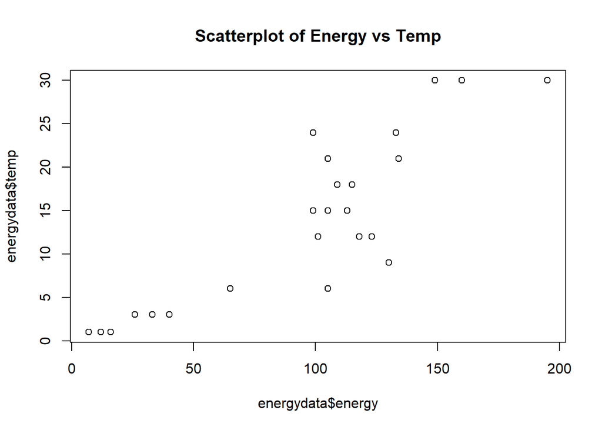

```r
plot(energydata$energy,energydata$temp, main="Scatterplot of Energy vs Temp")
```

The scatter of points suggests that there is a positive relationship between energy consumption and temperature. As energy consumption increases, the temperature also seems to increase.There are several clusters of points, especially noticeable in the lower range of energy consumption.There are a few points that stand out from the main cluster, particularly at higher energy consumptions. These could be outliers or could indicate a less consistent relationship at higher levels of energy consumption.: The overall trend could be described as linear, although with some degree of scatter.

```r
cor(energydata$energy,energydata$temp)
```

```
## [1] 0.868277
```

Correlation value of energy and temp is 0.87 which says they are strongly correlated.

2. Fit a cubic model (HINT: create two new variables TEMP2 and TEMP3: In R use the code: tempd2 = tempd^2; tempd3 = tempd^3; Include the new variables in the regression model)

```r
energydata$temp2 <- energydata$temp^2
energydata$temp3 <- energydata$temp^3

# Fit the cubic regression model
energy_model <- lm(energydata$energy ~ temp + temp2 + temp3, data = energydata)

# Output the summary of the model
summary(energy_model)
```

```
##
## Call:
## lm(formula = energydata$energy ~ temp + temp2 + temp3, data = energydata)
##
## Residuals:
##     Min      1Q  Median      3Q     Max
## -19.159 -11.257  -2.377   9.784  26.841
##
## Coefficients:
##               Estimate Std. Error t value Pr(>|t|)
## (Intercept) -17.036232  10.115284  -1.684    0.108
## temp         24.523999   3.371636   7.274 4.91e-07 ***
## temp2        -1.490029   0.266166  -5.598 1.77e-05 ***
## temp3         0.029278   0.005643   5.188 4.47e-05 ***
## ---
## Signif. codes:  0 '***' 0.001 '**' 0.01 '*' 0.05 '.' 0.1 ' ' 1
##
## Residual standard error: 15.73 on 20 degrees of freedom
## Multiple R-squared:  0.9137, Adjusted R-squared:  0.9008
## F-statistic: 70.62 on 3 and 20 DF,  p-value: 8.105e-11
```

3. Are all variables in the model significant?

```r
energy_model_summary <- summary(energy_model)
coeff_table <- energy_model_summary$coefficients

# Print the p-values
 p_values <- coeff_table[-1, "Pr(>|t|)"]>0.05
 print(p_values)
```

```
##  temp temp2 temp3
## FALSE FALSE FALSE
```

No,there are no non-significant variables in this model. All the variables are significant.

4. Create the residual plots (residuals vs predicted; residuals vs x variable; and normal plot of residuals). Analyze residual plots to evaluate the normality and constant variance assumptions. Discuss your findings

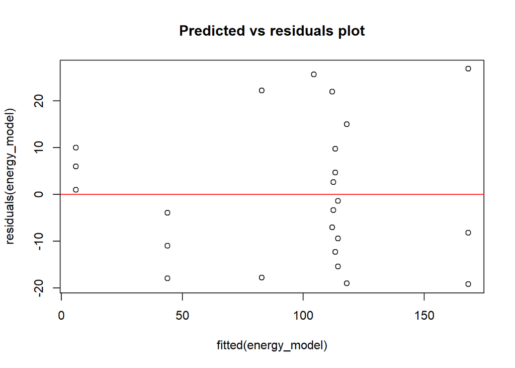

```r
plot( fitted(energy_model), residuals(energy_model), main="Predicted vs residuals plot")
abline(a=0, b=0, col='red')
```

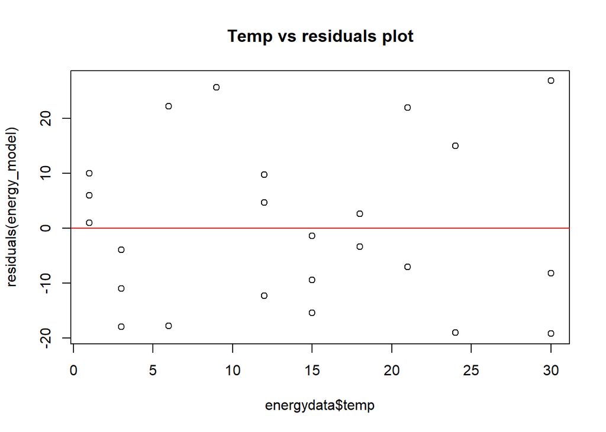

```r
plot( energydata$temp, residuals(energy_model), main="Temp vs residuals plot")
abline(a=0, b=0, col='red')
```

The residuals are relatively scattered around the horizontal line without a clear pattern, which generally suggests that the model does not have systematic errors in prediction across the range of temperatures. There are a few residuals with large magnitudes (both positive and negative), indicating points that the model did not predict accurately. The variance is relatively constant, which is a good indication. However, the cluster of points at the higher temperature values seems to have larger residuals, which might indicate potential issues with variance at higher temperatures.

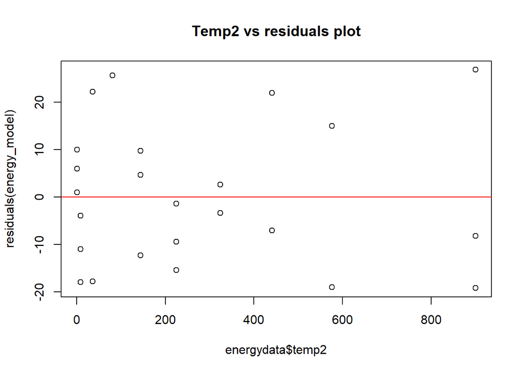

```r
plot( energydata$temp2, residuals(energy_model), main="Temp2 vs residuals plot")
abline(a=0, b=0, col='red')
```

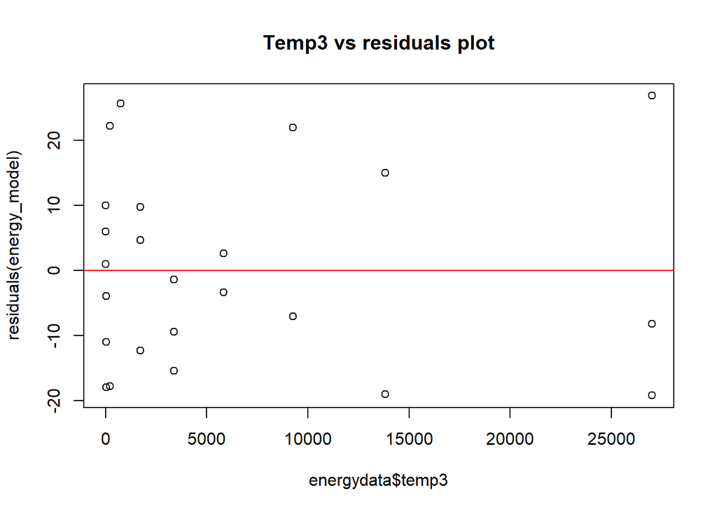

```r
plot( energydata$temp3, residuals(energy_model), main="Temp3 vs residuals plot")
abline(a=0, b=0, col='red')
```

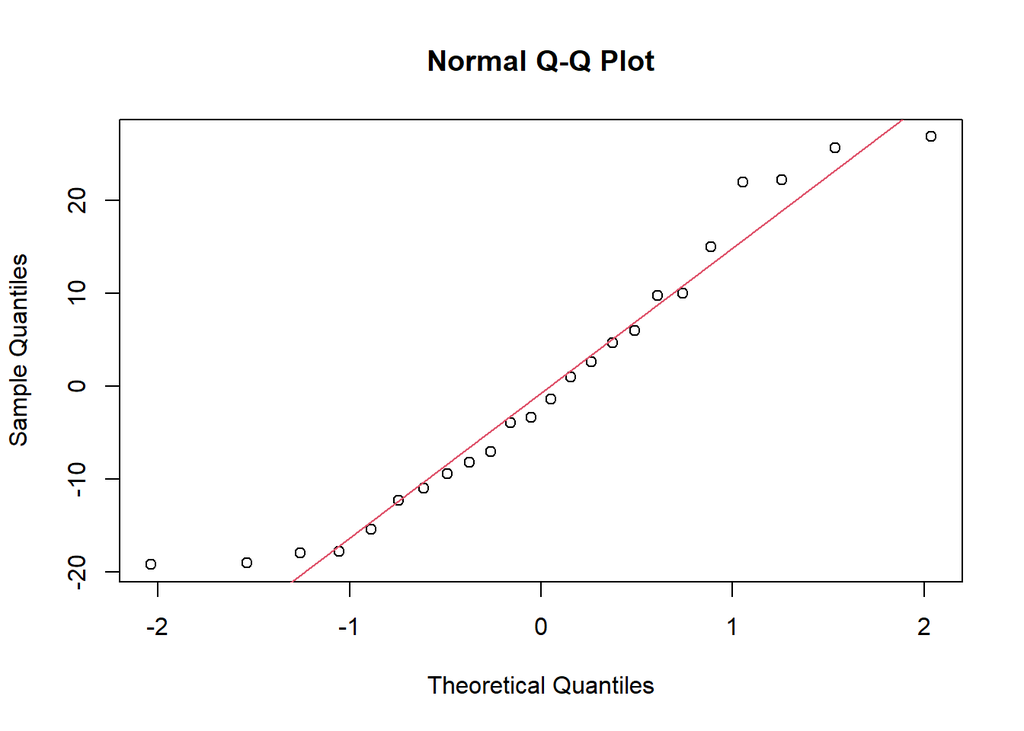

```r
qqnorm(residuals(energy_model))
qqline(residuals(energy_model), col = 2)
```

The points on this plot follow nearly a straight line. It shows normality of residuals. e) If you are satisfied with the fitted regression model, write down its expression.

```r
model_coefficients <- coef(energy_model)

# Construct the model expression
model_expression <- paste("energy = ",
                          round(model_coefficients[1], 2),
                          " + ", round(model_coefficients[2], 2), "*temp",
                          " + ", round(model_coefficients[3], 2), "*temp^2",
                          " + ", round(model_coefficients[4], 2), "*temp^3")

# Print the model expression
print(model_expression)
```

```
## [1] "energy =  -17.04  +  24.52 *temp  +  -1.49 *temp^2  +  0.03 *temp^3"
```

Expression: energy = -17.04 + 24.52 *temp + -1.49* temp^2 + 0.03 *temp^3

6. Use the fitted regression model to predict the average energy consumption for an average difference in temperature equal to TEMPD=10. (HINT: In R use the following code: new <- data.frame(tempd=c(10), tempd2=c(100), tempd3=c(1000)) then use the predict() function with the fitted regression model as explained in the document under week 5.

```r
#Prediction
energy_new_data <- data.frame(temp=c(10), temp2=c(100), temp3=c(1000))
predicted_energy <- predict(energy_model, newdata = energy_new_data)
print(predicted_energy)
```

```
##        1
## 108.4787
```

The predicted energy is 108.4787 .